# heba-aamer: Traffic Data Analysis

### Reading and Processing Data

This section is responsible for reading the data and cleaning it.

#### Data Reading

```r
be2olak.data <- read.csv("../all-semi-unique.csv")
names(be2olak.data)
```

```
##  [1] "crawl_date"      "ad.aid"          "ad.bgcl"
##  [4] "ad.bgcls"        "ad.fncl"         "ad.fncls"
##  [7] "ad.lid"          "ad.logo"         "ad.logo2x"
## [10] "ad.logoAndroidS" "ad.logoAndroidH" "ad.cm"
## [13] "ad.url"          "ad.g"            "rd.nm"
## [16] "rd.ri"           "rd.stid"         "rd.hr"
## [19] "rd.mn"           "rd.new"          "rd.img"
## [22] "rd.cl"           "rd.strq"         "rd.cmrq"
## [25] "rd.rp.nm"        "rd.rp.fullnm"    "rd.rp.hr"
## [28] "rd.rp.mn"        "rd.rp.stid"      "rd.rp.cm"
## [31] "rd.rp.cmid"      "rd.rp.rpImg"     "rd.rp.img"
## [34] "rd.rp.type"
```

```r
str(be2olak.data)
```

```
## 'data.frame':    429982 obs. of  34 variables:
##  $ crawl_date     : Factor w/ 28331 levels "Fri Feb 12 00:00:14 UTC 2016",..: 1869 1869 1869 1869 8758 8758 8809 8809 8862 8862 ...
##  $ ad.aid         : int  2538 2538 2538 2538 2538 2538 2538 2538 2538 2538 ...
##  $ ad.bgcl        : Factor w/ 1 level "#003768": 1 1 1 1 1 1 1 1 1 1 ...
##  $ ad.bgcls       : Factor w/ 1 level "#0069aa": 1 1 1 1 1 1 1 1 1 1 ...
##  $ ad.fncl        : Factor w/ 1 level "#FFFFFF": 1 1 1 1 1 1 1 1 1 1 ...
##  $ ad.fncls       : Factor w/ 1 level "#FFFFFF": 1 1 1 1 1 1 1 1 1 1 ...
##  $ ad.lid         : int  1001 1001 1001 1001 1001 1001 1001 1001 1001 1001 ...
##  $ ad.logo        : Factor w/ 1 level "http://www.bey2ollak.com/downloads/logos/Pepsi_SA7EL.png": 1 1 1 1 1 1 1 1 1 1 ...
##  $ ad.logo2x      : Factor w/ 1 level "http://www.bey2ollak.com/downloads/logos/Pepsi_SA7EL@2x.png": 1 1 1 1 1 1 1 1 1 1 ...
##  $ ad.logoAndroidS: Factor w/ 1 level "http://www.bey2ollak.com/downloads/logos/Pepsi_SA7EL_ANDROID_S.png": 1 1 1 1 1 1 1 1 1 1 ...
##  $ ad.logoAndroidH: Factor w/ 1 level "http://www.bey2ollak.com/downloads/logos/Pepsi_SA7EL_ANDROID_H.png": 1 1 1 1 1 1 1 1 1 1 ...
##  $ ad.cm          : Factor w/ 1 level "دوس هنا وشوف إعلان بيبسي الجديد مع محمد صلاح #يلا_تقدر": 1 1 1 1 1 1 1 1 1 1 ...
##  $ ad.url         : Factor w/ 1 level "http://youtu.be/aNeqShdgupY": 1 1 1 1 1 1 1 1 1 1 ...
##  $ ad.g           : int  1 1 1 1 1 1 1 1 1 1 ...
```

[output cut: 20 more lines]

```r
dim(be2olak.data)
```

```
## [1] 429982     34
```

#### Data Cleaning

The aim of this section:

- Remove not needed columns
- Remove duplicated rows
- Remove NAs

#### Removing not needed columns

By analyzing the distribution of some columns, I found that some of the columns only have one value, so these columns are not needed and should be deleted from the data.

```r
column_count = sapply(be2olak.data, function(x) length(unique(x)))
be2olak.data <- be2olak.data[, !names(be2olak.data) %in% names(column_count[column_count ==
    1])]
```

Moreover, the 6 columns (rd.stid, rd.hr, rd.mn, rd.rp.fullnm, rd.img, rd.rp.img) are meaningless and want add anything to the data so I will remove them:

```r
columns.delete = c("rd.stid", "rd.hr", "rd.mn", "rd.rp.fullnm", "rd.img", "rd.rp.img")
```

```r
be2olak.data <- be2olak.data[, !names(be2olak.data) %in% columns.delete]
```

```r
stargazer(be2olak.data, type = "text", title = "Descriptive statistics")
```

```
##
## Descriptive statistics
## ================================================================
## Statistic      N        Mean       St. Dev.     Min       Max
## ----------------------------------------------------------------
## rd.ri       429,982    297.596     203.760       5        699
## rd.new      429,982     0.074       0.262        0         1
## rd.strq     429,982     0.949       0.219        0         1
## rd.cmrq     429,982     0.072       0.259        0         1
## rd.rp.hr    429,982     8.708       8.169        0        140
## rd.rp.mn    429,982    29.197       17.295       0        59
## rd.rp.stid  416,017     4.710       3.374        1        10
## rd.rp.cmid  429,982 9,376,278.000 43,625.590 9,271,509 9,452,302
## rd.rp.rpImg 18,397   461,013.800  13,341.540  21,970    467,309
## ----------------------------------------------------------------
```

#### Removing Duplicated Rows

Now we need only to keep the unique rows and remove any duplicates. In order to do that, I checked the number of unique rows with respect to more than one combination of columns to get what really affect the data.

```r
# with respect to comment id
nrow(unique(be2olak.data[c("rd.rp.cmid")]))
```

```
## [1] 148367
```

```r
# with respect to status id, and comment id
nrow(unique(be2olak.data[c("rd.rp.stid", "rd.rp.cmid")]))
```

```
## [1] 148927
```

```r
# with respect to road index, status id, and comment id
nrow(unique(be2olak.data[c("rd.ri", "rd.rp.stid", "rd.rp.cmid")]))
```

```
## [1] 157280
```

From the results presented above, the combination of (road index, status id, and comment id) would make the report entry unique.

So now I will remove duplicated rows.

```r
be2olak.data <- be2olak.data[!duplicated(be2olak.data[, which(colnames(be2olak.data) %in%
    c("rd.rp.cmid", "rd.rp.stid", "rd.ri"))]), ]
```

Checking data summary again after removing the duplicated rows:

```r
dim(be2olak.data)
```

```
## [1] 157280     13
```

```r
stargazer(be2olak.data, type = "text", title = "Bey2ollak Data")
```

```
##
## Bey2ollak Data
## ================================================================
## Statistic      N        Mean       St. Dev.     Min       Max
## ----------------------------------------------------------------
## rd.ri       157,280    306.540     204.588       5        699
## rd.new      157,280     0.073       0.259        0         1
## rd.strq     157,280     0.909       0.287        0         1
## rd.cmrq     157,280     0.111       0.314        0         1
## rd.rp.hr    157,280     7.762       8.060        0        139
## rd.rp.mn    157,280    28.114       17.239       0        59
## rd.rp.stid  147,825     4.726       3.360        1        10
## rd.rp.cmid  157,280 9,375,958.000 43,933.480 9,271,509 9,452,302
## rd.rp.rpImg  6,304   461,046.600  13,933.820  21,970    467,309
## ----------------------------------------------------------------
```

```r
summary(be2olak.data)
```

```
##                         crawl_date
##  Sun Feb 14 22:30:08 UTC 2016:   120
##  Sun Feb 14 22:30:10 UTC 2016:   120
##  Sun Feb 14 22:30:11 UTC 2016:   120
##  Sun Feb 14 22:30:15 UTC 2016:   120
##  Sun Feb  7 22:30:18 UTC 2016:   120
##  Sun Feb  7 22:30:25 UTC 2016:   120
##  (Other)                     :156560
##                                     rd.nm            rd.ri
##  Sa7rawy;Cairo To Alex                 :  6933   Min.   :  5.0
##  Sa7rawy;Alex To Cairo                 :  5242   1st Qu.:159.0
##  Kobry 6 October;Madinet Nasr To Ta7rir:  3221   Median :262.0
##  Da2ery;Moneeb To Autostrad            :  3085   Mean   :306.5
##  Da2ery;Autostrad To Moneeb            :  3012   3rd Qu.:520.0
##  Kobry 6 October;Mohandesin To Ta7rir  :  2871   Max.   :699.0
##  (Other)                               :132916
##      rd.new           rd.strq          rd.cmrq
##  Min.   :0.00000   Min.   :0.0000   Min.   :0.0000
##  1st Qu.:0.00000   1st Qu.:1.0000   1st Qu.:0.0000
##  Median :0.00000   Median :1.0000   Median :0.0000
##  Mean   :0.07258   Mean   :0.9091   Mean   :0.1111
##  3rd Qu.:0.00000   3rd Qu.:1.0000   3rd Qu.:0.0000
##  Max.   :1.00000   Max.   :1.0000   Max.   :1.0000
##
##                 rd.rp.nm        rd.rp.hr          rd.rp.mn
##  bey2ollakgps       :59509   Min.   :  0.000   Min.   : 0.00
##  fa3el kheir        :15769   1st Qu.:  1.000   1st Qu.:13.00
##  SuperSafwat        :  616   Median :  5.000   Median :27.00
##  waleedm            :  481   Mean   :  7.762   Mean   :28.11
##  Tootchy            :  465   3rd Qu.: 12.000   3rd Qu.:43.00
##  kareemabdelkareem90:  428   Max.   :139.000   Max.   :59.00
##  (Other)            :80012
##    rd.rp.stid              rd.rp.cm        rd.rp.cmid
##  Min.   : 1.000   lazeez       : 26034   Min.   :9271509
##  1st Qu.: 2.000   mashy        :  7493   1st Qu.:9338431
##  Median : 3.000   7alawa       :  5820   Median :9375404
##  Mean   : 4.726   Eih el nezam?:  5073   Mean   :9375958
##  3rd Qu.:10.000   za7ma        :  5022   3rd Qu.:9414170
##  Max.   :10.000   mafeesh amal :  2962   Max.   :9452302
##  NA's   :9455     (Other)      :104876
##   rd.rp.rpImg
##  Min.   : 21970
##  1st Qu.:458627
##  Median :461526
##  Mean   :461047
##  3rd Qu.:464282
##  Max.   :467309
##  NA's   :150976
```

```r
str(be2olak.data)
```

```
## 'data.frame':    157280 obs. of  13 variables:
##  $ crawl_date : Factor w/ 28331 levels "Fri Feb 12 00:00:14 UTC 2016",..: 1869 1869 1869 1869 8758 8758 8916 9147 9513 9513 ...
##  $ rd.nm      : Factor w/ 301 levels "14 Mayo Road;Kobry 14 Mayo To Mad5al Smou7a",..: 163 163 163 163 163 163 163 163 163 163 ...
##  $ rd.ri      : int  678 678 678 678 678 678 678 678 678 678 ...
##  $ rd.new     : int  1 1 1 1 1 1 1 1 1 1 ...
##  $ rd.strq    : int  1 1 1 1 1 1 1 1 1 1 ...
##  $ rd.cmrq    : int  0 0 0 0 0 0 0 0 0 0 ...
##  $ rd.rp.nm   : Factor w/ 16759 levels "007","01006034540",..: 15208 92 6017 14435 6297 6087 12001 13600 4039 4039 ...
##  $ rd.rp.hr   : int  18 20 22 23 23 28 23 23 23 24 ...
##  $ rd.rp.mn   : int  38 26 6 47 32 56 5 15 53 13 ...
##  $ rd.rp.stid : int  2 2 2 2 2 1 2 2 3 3 ...
##  $ rd.rp.cm   : Factor w/ 44716 levels ";(",":-(",":/",..: 15605 15605 15605 15605 15605 1368 15605 15605 25147 19013 ...
##  $ rd.rp.cmid : int  9300046 9299640 9299068 9298351 9300548 9300224 9301083 9301656 9302773 9302649 ...
##  $ rd.rp.rpImg: int  NA NA NA NA NA NA NA NA NA NA ...
```

#### Investigate NAs

First, lets check the proportion of NAs:

```r
length(be2olak.data[is.na(be2olak.data)])/(ncol(be2olak.data) * nrow(be2olak.data))
```

```
## [1] 0.07846418
```

And from the summary results the Nas are there because of 2 columns (rd.rp.stid , rd.rp.rpImg)

So for rd.rp.rpImg, it means that the reporter has uploaded a photo for the road. Otherwise, it means the he/she did not.

So for my analysis, I am not concerned with photo itself, I am only concerned with the uploading action. So I will remove this column after adding one that has “YES” or “NO” representing whether this report has an uploaded photo or not.

```r
be2olak.data$rp.has.photo <- as.factor(ifelse(is.na(be2olak.data$rd.rp.rpImg),
    "NO", "YES"))
be2olak.data$rd.rp.rpImg <- NULL
```

So check on the proportion of NAs again

```r
length(be2olak.data[is.na(be2olak.data)])/(ncol(be2olak.data) * nrow(be2olak.data))
```

```
## [1] 0.004624286
```

```r
dim(be2olak.data)
```

```
## [1] 157280     13
```

```r
stargazer(be2olak.data, type = "text", title = "Bey2ollak Data")
```

```
##
## Bey2ollak Data
## ===============================================================
## Statistic     N        Mean       St. Dev.     Min       Max
## ---------------------------------------------------------------
## rd.ri      157,280    306.540     204.588       5        699
## rd.new     157,280     0.073       0.259        0         1
## rd.strq    157,280     0.909       0.287        0         1
## rd.cmrq    157,280     0.111       0.314        0         1
## rd.rp.hr   157,280     7.762       8.060        0        139
## rd.rp.mn   157,280    28.114       17.239       0        59
## rd.rp.stid 147,825     4.726       3.360        1        10
## rd.rp.cmid 157,280 9,375,958.000 43,933.480 9,271,509 9,452,302
## ---------------------------------------------------------------
```

```r
summary(be2olak.data)
```

```
##                         crawl_date
##  Sun Feb 14 22:30:08 UTC 2016:   120
##  Sun Feb 14 22:30:10 UTC 2016:   120
##  Sun Feb 14 22:30:11 UTC 2016:   120
##  Sun Feb 14 22:30:15 UTC 2016:   120
##  Sun Feb  7 22:30:18 UTC 2016:   120
##  Sun Feb  7 22:30:25 UTC 2016:   120
##  (Other)                     :156560
##                                     rd.nm            rd.ri
##  Sa7rawy;Cairo To Alex                 :  6933   Min.   :  5.0
##  Sa7rawy;Alex To Cairo                 :  5242   1st Qu.:159.0
##  Kobry 6 October;Madinet Nasr To Ta7rir:  3221   Median :262.0
##  Da2ery;Moneeb To Autostrad            :  3085   Mean   :306.5
##  Da2ery;Autostrad To Moneeb            :  3012   3rd Qu.:520.0
##  Kobry 6 October;Mohandesin To Ta7rir  :  2871   Max.   :699.0
##  (Other)                               :132916
##      rd.new           rd.strq          rd.cmrq
##  Min.   :0.00000   Min.   :0.0000   Min.   :0.0000
##  1st Qu.:0.00000   1st Qu.:1.0000   1st Qu.:0.0000
##  Median :0.00000   Median :1.0000   Median :0.0000
##  Mean   :0.07258   Mean   :0.9091   Mean   :0.1111
##  3rd Qu.:0.00000   3rd Qu.:1.0000   3rd Qu.:0.0000
##  Max.   :1.00000   Max.   :1.0000   Max.   :1.0000
##
##                 rd.rp.nm        rd.rp.hr          rd.rp.mn
##  bey2ollakgps       :59509   Min.   :  0.000   Min.   : 0.00
##  fa3el kheir        :15769   1st Qu.:  1.000   1st Qu.:13.00
##  SuperSafwat        :  616   Median :  5.000   Median :27.00
##  waleedm            :  481   Mean   :  7.762   Mean   :28.11
##  Tootchy            :  465   3rd Qu.: 12.000   3rd Qu.:43.00
##  kareemabdelkareem90:  428   Max.   :139.000   Max.   :59.00
##  (Other)            :80012
##    rd.rp.stid              rd.rp.cm        rd.rp.cmid      rp.has.photo
##  Min.   : 1.000   lazeez       : 26034   Min.   :9271509   NO :150976
##  1st Qu.: 2.000   mashy        :  7493   1st Qu.:9338431   YES:  6304
##  Median : 3.000   7alawa       :  5820   Median :9375404
##  Mean   : 4.726   Eih el nezam?:  5073   Mean   :9375958
##  3rd Qu.:10.000   za7ma        :  5022   3rd Qu.:9414170
##  Max.   :10.000   mafeesh amal :  2962   Max.   :9452302
##  NA's   :9455     (Other)      :104876
```

```r
str(be2olak.data)
```

```
## 'data.frame':    157280 obs. of  13 variables:
##  $ crawl_date  : Factor w/ 28331 levels "Fri Feb 12 00:00:14 UTC 2016",..: 1869 1869 1869 1869 8758 8758 8916 9147 9513 9513 ...
##  $ rd.nm       : Factor w/ 301 levels "14 Mayo Road;Kobry 14 Mayo To Mad5al Smou7a",..: 163 163 163 163 163 163 163 163 163 163 ...
##  $ rd.ri       : int  678 678 678 678 678 678 678 678 678 678 ...
##  $ rd.new      : int  1 1 1 1 1 1 1 1 1 1 ...
##  $ rd.strq     : int  1 1 1 1 1 1 1 1 1 1 ...
##  $ rd.cmrq     : int  0 0 0 0 0 0 0 0 0 0 ...
##  $ rd.rp.nm    : Factor w/ 16759 levels "007","01006034540",..: 15208 92 6017 14435 6297 6087 12001 13600 4039 4039 ...
##  $ rd.rp.hr    : int  18 20 22 23 23 28 23 23 23 24 ...
##  $ rd.rp.mn    : int  38 26 6 47 32 56 5 15 53 13 ...
##  $ rd.rp.stid  : int  2 2 2 2 2 1 2 2 3 3 ...
##  $ rd.rp.cm    : Factor w/ 44716 levels ";(",":-(",":/",..: 15605 15605 15605 15605 15605 1368 15605 15605 25147 19013 ...
##  $ rd.rp.cmid  : int  9300046 9299640 9299068 9298351 9300548 9300224 9301083 9301656 9302773 9302649 ...
##  $ rp.has.photo: Factor w/ 2 levels "NO","YES": 1 1 1 1 1 1 1 1 1 1 ...
```

Now lets get to the other column which is the rd.rp.stid

#### Exploring the NAs of the rd.rp.stid column

Note, here is a function taken from online resource that I will be using in my analysis

```r
freqfunc <- function(x, n) {
    tail(sort(table(unlist(strsplit(as.character(x), ", ")))), n)
}
```

Ok, Let get only the rows where rd.rp.stid is NA

```r
missing.stid <- be2olak.data[is.na(be2olak.data$rd.rp.stid), c("rd.rp.cm", "rd.nm")]
str(missing.stid)
```

```
## 'data.frame':    9455 obs. of  2 variables:
##  $ rd.rp.cm: Factor w/ 44716 levels ";(",":-(",":/",..: 19958 28859 3497 2429 4070 181 33793 14678 32035 20136 ...
##  $ rd.nm   : Factor w/ 301 levels "14 Mayo Road;Kobry 14 Mayo To Mad5al Smou7a",..: 223 223 223 223 223 223 223 223 223 223 ...
```

```r
summary(missing.stid)
```

```
##                      rd.rp.cm
##  clear till master       : 103
##  clear till gates        :  39
##  clear till 80           :  26
##  clear till 100          :  24
##  any updates             :  19
##  any update b3d al master:  16
##  (Other)                 :9228
##                                       rd.nm
##  Sa7rawy;Cairo To Alex                   :4732
##  Sa7rawy;Alex To Cairo                   :3712
##  Sokhna/Gharda2ah Rd.;Cairo To Gharda2ah : 516
##  Gharda2ah/Sokhna Rd.; Gharda2ah To Cairo: 427
##  Other Roads                             :  21
##  Sharm Rd;Nafa2 ElShaheed To 3oyoun Mousa:  13
##  (Other)                                 :  34
```

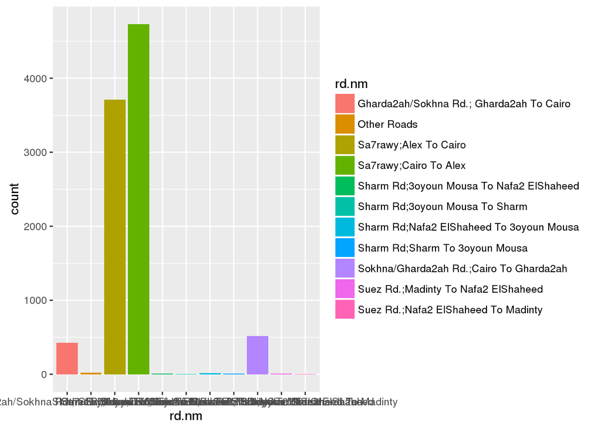

```r
ggplot(missing.stid, aes(x = rd.nm, fill = rd.nm)) + geom_bar()
```

checking most of the comments in those reports

```r
freqfunc(missing.stid$rd.rp.cm, 60)
```

```
##
##                              تمام حتى النوباريه
##                                               6
##                                          خطر 91
##                                               6
##                            رادار عند الكيلو 150
##                                               6
## صباح الخير يا مصر الرادر فين على اتجاه اسكندرية
##                                               6
##                          لحد السادات مافيش حاجة
##                                               6
##                                      any radars
##                                               7
##                                    Any update ?
##                                               7
##                                  clear till 119
##                                               7
##                                   clear till 78
##                                               7
##                                   clear till 85
##                                               7
##                                      Fe radarat
##                                               7
##                                              no
##                                               7
##                                       radar 165
##                                               7
##                       ايه اخبار الرادار يا شباب
##                                               7
##                                  لحد ماستر تمام
##                                               7
##                                             150
##                                               8
##                               clear all the way
##                                               8
##                                  clear till 155
##                                               8
##                                  clear till 170
##                                               8
##                                   clear till 45
```

[output cut: 66 more lines]

```
##                                              15
##                        any update b3d al master
##                                              16
##                                           clear
##                                              16
##                                     any updates
##                                              19
##                                   clear till 80
##                                              26
##                                  clear till 100
##                                              27
##                                clear till gates
##                                              39
##                               clear till master
##                                             103
```

So after analyzing the rows that has stid with NAs so mainly they are highway roads and roads connecting between cities.

Moreover, The comments are mainly about asking about radar and reporting radars or clear statuses.

Those type of roads would need another analysis, but for my analysis I would remove those entries from the original data frame since they are not relevant.

```r
be2olak.data <- be2olak.data %>% filter(!is.na(rd.rp.stid))
```

Now check that all NAs have been removed

```r
length(be2olak.data[is.na(be2olak.data)])
```

```
## [1] 0
```

### Feature Engineering

In this section, I will do some feature engineering.

#### Format Crawl Date in a better way

The crawling date is presented in a way that we could make a use of to get the other columns that might help in viewing relations between columns.

Moreover, it will allow us to get the actual date of report from a user, which in case of “za7ma” reports for example, it will get the actual time of the phenomenon.

- First, is to split the crawl date into week day, month, month day, crawl-date (as hours - minutes - seconds) only.
- Then form a new column representing this a formated crawling date.
- Then get the actual reports date (taking into consideration the difference between EET and UCT).

```r
be2olak.data <- be2olak.data %>% separate(crawl_date, c("week.day", "month",
    "month.day", "crawl.date"), extra = "drop", sep = "[ ]+", convert = T, remove = T) %>%
    unite(crawl.time, week.day, month, month.day, crawl.date, sep = " ", remove = F)
be2olak.data$formated.date <- as.POSIXct(strptime(be2olak.data$crawl.time, format = "%a %b %d %H:%M:%S"))
be2olak.data$week.day <- as.factor(be2olak.data$week.day)
```

Get the hour of the report

```r
be2olak.data$report.hr <- hour(be2olak.data$formated.date)
```

#### Get Comment’s Actual Time

```r
# Adding 2 hours to get Egypt's local time instead of UTC Remove the
# duration of the report has been posted presented by rd.rp.hr and rd.rp.mn

be2olak.data$comment.time <- be2olak.data$formated.date + hours(2) - hours(be2olak.data$rd.rp.hr) -
    minutes(be2olak.data$rd.rp.mn)
```

Then remove not needed columns in this case

```r
be2olak.data$formated.date <- NULL
be2olak.data$rd.rp.hr <- NULL
be2olak.data$rd.rp.mn <- NULL
be2olak.data$crawl.date <- NULL
be2olak.data$crawl.time <- NULL
# Moreover, month would not be needed since it is the same for all the data
be2olak.data$month <- NULL
```

Then check the stats of the dataframe

```r
str(be2olak.data)
```

```
## 'data.frame':    147825 obs. of  14 variables:
##  $ week.day    : Factor w/ 7 levels "Fri","Mon","Sat",..: 1 1 1 1 3 3 3 3 3 3 ...
##  $ month.day   : int  5 5 5 5 6 6 6 6 6 6 ...
##  $ rd.nm       : Factor w/ 301 levels "14 Mayo Road;Kobry 14 Mayo To Mad5al Smou7a",..: 163 163 163 163 163 163 163 163 163 163 ...
##  $ rd.ri       : int  678 678 678 678 678 678 678 678 678 678 ...
##  $ rd.new      : int  1 1 1 1 1 1 1 1 1 1 ...
##  $ rd.strq     : int  1 1 1 1 1 1 1 1 1 1 ...
##  $ rd.cmrq     : int  0 0 0 0 0 0 0 0 0 0 ...
##  $ rd.rp.nm    : Factor w/ 16759 levels "007","01006034540",..: 15208 92 6017 14435 6297 6087 12001 13600 4039 4039 ...
##  $ rd.rp.stid  : int  2 2 2 2 2 1 2 2 3 3 ...
##  $ rd.rp.cm    : Factor w/ 44716 levels ";(",":-(",":/",..: 15605 15605 15605 15605 15605 1368 15605 15605 25147 19013 ...
##  $ rd.rp.cmid  : int  9300046 9299640 9299068 9298351 9300548 9300224 9301083 9301656 9302773 9302649 ...
##  $ rp.has.photo: Factor w/ 2 levels "NO","YES": 1 1 1 1 1 1 1 1 1 1 ...
##  $ report.hr   : int  17 17 17 17 8 8 9 11 14 14 ...
##  $ comment.time: POSIXct, format: "2016-02-05 00:45:57" "2016-02-04 22:57:57" ...
```

```r
summary(be2olak.data)
```

```
##  week.day      month.day
##  Fri: 7611   Min.   : 5.00
##  Mon: 9926   1st Qu.:10.00
##  Sat:20674   Median :14.00
##  Sun:33170   Mean   :13.86
##  Thu:22870   3rd Qu.:17.00
##  Tue:21996   Max.   :21.00
##  Wed:31578
##                                     rd.nm            rd.ri
##  Kobry 6 October;Madinet Nasr To Ta7rir:  3221   Min.   :  5.0
##  Da2ery;Moneeb To Autostrad            :  3085   1st Qu.:148.0
##  Da2ery;Autostrad To Moneeb            :  3012   Median :254.0
##  Kobry 6 October;Mohandesin To Ta7rir  :  2871   Mean   :296.5
##  Kobry 6 October;Ta7rir To Mohandesin  :  2325   3rd Qu.:478.0
##  Kobry 6 October;Ta7rir To Madinet Nasr:  2254   Max.   :699.0
##  (Other)                               :131057
##      rd.new           rd.strq          rd.cmrq
##  Min.   :0.00000   Min.   :0.0000   Min.   :0.00000
##  1st Qu.:0.00000   1st Qu.:1.0000   1st Qu.:0.00000
##  Median :0.00000   Median :1.0000   Median :0.00000
##  Mean   :0.07723   Mean   :0.9672   Mean   :0.05424
##  3rd Qu.:0.00000   3rd Qu.:1.0000   3rd Qu.:0.00000
##  Max.   :1.00000   Max.   :1.0000   Max.   :1.00000
##
##                 rd.rp.nm       rd.rp.stid              rd.rp.cm
##  bey2ollakgps       :59509   Min.   : 1.000   lazeez       :26034
##  fa3el kheir        :14484   1st Qu.: 2.000   mashy        : 7493
##  SuperSafwat        :  616   Median : 3.000   7alawa       : 5820
##  waleedm            :  481   Mean   : 4.726   Eih el nezam?: 5073
##  Tootchy            :  465   3rd Qu.:10.000   za7ma        : 5021
##  kareemabdelkareem90:  428   Max.   :10.000   mafeesh amal : 2962
##  (Other)            :71842                    (Other)      :95422
##    rd.rp.cmid      rp.has.photo   report.hr
##  Min.   :9271509   NO :141531   Min.   : 0.00
##  1st Qu.:9338256   YES:  6294   1st Qu.: 9.00
##  Median :9376110                Median :14.00
##  Mean   :9376126                Mean   :14.13
##  3rd Qu.:9414054                3rd Qu.:20.00
##  Max.   :9452302                Max.   :23.00
##
##   comment.time
##  Min.   :2016-02-01 20:46:42
##  1st Qu.:2016-02-10 07:19:06
##  Median :2016-02-14 21:41:17
##  Mean   :2016-02-14 04:35:18
##  3rd Qu.:2016-02-18 01:15:39
##  Max.   :2016-02-21 10:30:46
##
```

```r
glimpse(be2olak.data)
```

```
## Observations: 147,825
## Variables: 14
## $ week.day     (fctr) Fri, Fri, Fri, Fri, Sat, Sat, Sat, Sat, Sat, Sat...
## $ month.day    (int) 5, 5, 5, 5, 6, 6, 6, 6, 6, 6, 6, 6, 6, 6, 7, 7, 7...
## $ rd.nm        (fctr) Makram 3ebeid;Autostrad To Mostafa ElNa7as, Makr...
## $ rd.ri        (int) 678, 678, 678, 678, 678, 678, 678, 678, 678, 678,...
## $ rd.new       (int) 1, 1, 1, 1, 1, 1, 1, 1, 1, 1, 1, 1, 1, 1, 1, 1, 1...
## $ rd.strq      (int) 1, 1, 1, 1, 1, 1, 1, 1, 1, 1, 1, 1, 1, 1, 1, 1, 1...
## $ rd.cmrq      (int) 0, 0, 0, 0, 0, 0, 0, 0, 0, 0, 0, 0, 0, 0, 0, 0, 0...
## $ rd.rp.nm     (fctr) Tahany_Eyad, 7abeba_Sa3d, fa3el kheir, ShahinazS...
## $ rd.rp.stid   (int) 2, 2, 2, 2, 2, 1, 2, 2, 3, 3, 2, 3, 2, 2, 2, 2, 2...
## $ rd.rp.cm     (fctr) lazeez, lazeez, lazeez, lazeez, lazeez, 7alawa, ...
## $ rd.rp.cmid   (int) 9300046, 9299640, 9299068, 9298351, 9300548, 9300...
## $ rp.has.photo (fctr) NO, NO, NO, NO, NO, NO, NO, NO, NO, NO, NO, NO, ...
## $ report.hr    (int) 17, 17, 17, 17, 8, 8, 9, 11, 14, 14, 14, 15, 18, ...
## $ comment.time (time) 2016-02-05 00:45:57, 2016-02-04 22:57:57, 2016-0...
```

#### Add the city for each entry

Another thing that could be done related to augmenting the data, is to add a column representing the city of each the road being reported on, whether it is “cairo” or “alex”. And this is done in the next section.

First, get the ids of the roads in Cairo.

```r
# Get Cairo Road ids

doc <- htmlParse("http://www.bey2ollak.com/Bey2ollak/Traffic?action=getTraffic&ver=1.0&w=320&h=240&deviceType=10&lang=1&protocol=1&city=0&lang=1")
cairo.roads.id <- sapply(getNodeSet(doc, "//ri"), function(x) as.integer(xmlValue(x)))
length(cairo.roads.id)
```

```
## [1] 204
```

Then, get the ids of the roads in Alex.

```r
# Get Alex Road ids

doc <- htmlParse("http://www.bey2ollak.com/Bey2ollak/Traffic?action=getTraffic&ver=1.0&w=320&h=240&deviceType=10&lang=1&protocol=1&city=1&lang=1")
alex.roads.id <- sapply(getNodeSet(doc, "//ri"), function(x) as.integer(xmlValue(x)))
length(alex.roads.id)
```

```
## [1] 111
```

Then, add column representing the city in each row in the dataframe.

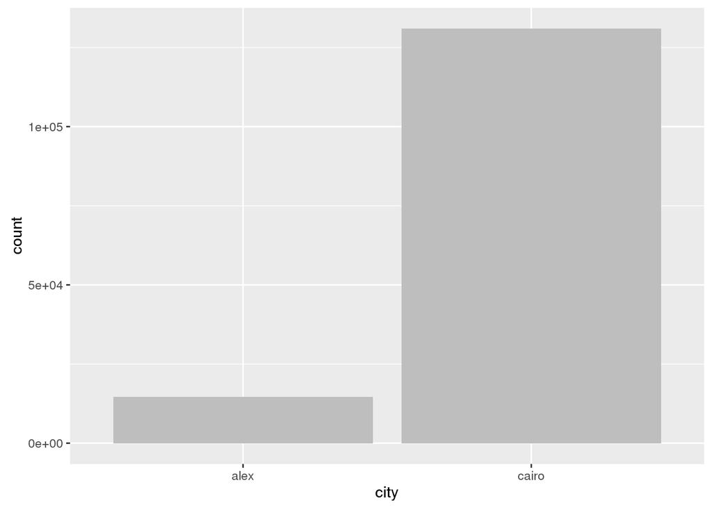

```r
be2olak.data$city[(be2olak.data$rd.ri %in% cairo.roads.id)] = "cairo"
be2olak.data$city[(be2olak.data$rd.ri %in% alex.roads.id)] = "alex"
# be2olak.data$city <- as.factor(be2olak.data$city)
ggplot(be2olak.data) + geom_bar(aes(x = city), fill = "gray")
```

Now check in who many rows city is NA.

```r
unique(be2olak.data$rd.nm[is.na(be2olak.data$city)])
```

```
## [1] Makram 3ebeid;Autostrad To Mostafa ElNa7as
## [2] Gam3et ElDewal St;Sudan St To Sphinx
## [3] Sa7rawy;Alex To Cairo
## [4] Tagamo3
## [5] Sa7rawy;Cairo To Alex
## [6] توتال (برج العرب)
## 301 Levels: 14 Mayo Road;Kobry 14 Mayo To Mad5al Smou7a ...
```

```r
be2olak.data$city <- NULL
```

#### Get the main road name from rd.nm

Another thing that could be done is to make a new column (road.main) from the rd.nm which is the first part of the road name, since this might introduce some visualisations or relations between two sides of the road.

```r
be2olak.data <- be2olak.data %>% separate(rd.nm, c("road.main"), extra = "drop",
    sep = ";", convert = F, remove = F)
be2olak.data$road.main <- as.factor(be2olak.data$road.main)
```

### Plotting graphs for the different columns

First, Plotting the integer columns and Factored columns.

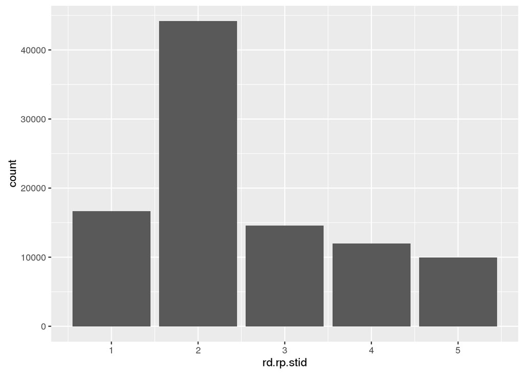

```r
be2olak.data.filtered <- be2olak.data %>% filter(rd.rp.stid < 6)
# Integer Columns
ggplot(be2olak.data.filtered, aes(x = rd.rp.stid)) + geom_bar()
```

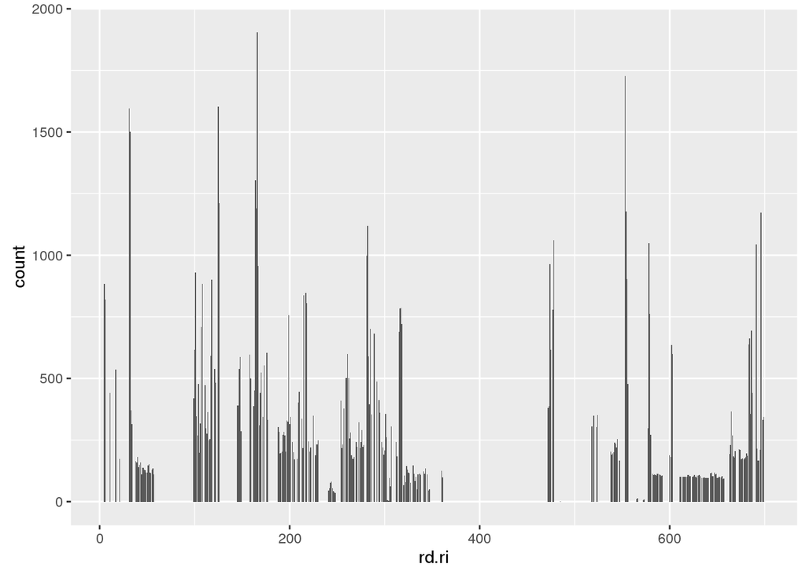

```r
ggplot(be2olak.data.filtered, aes(x = rd.ri)) + geom_bar()
```

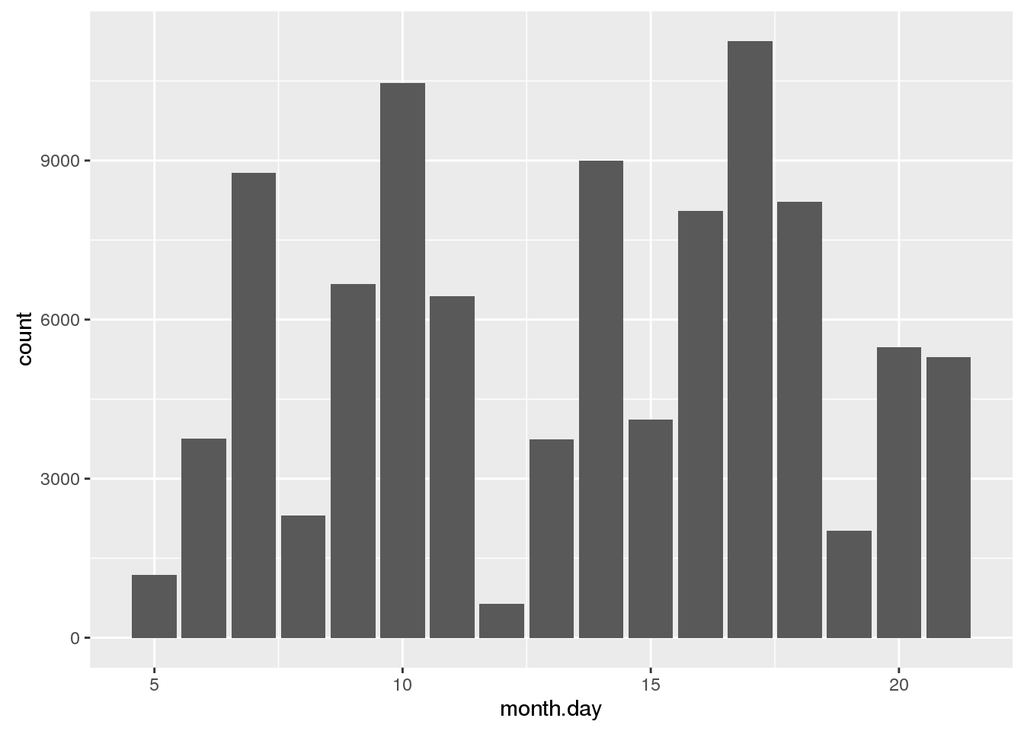

```r
ggplot(be2olak.data.filtered, aes(x = month.day)) + geom_bar()
```

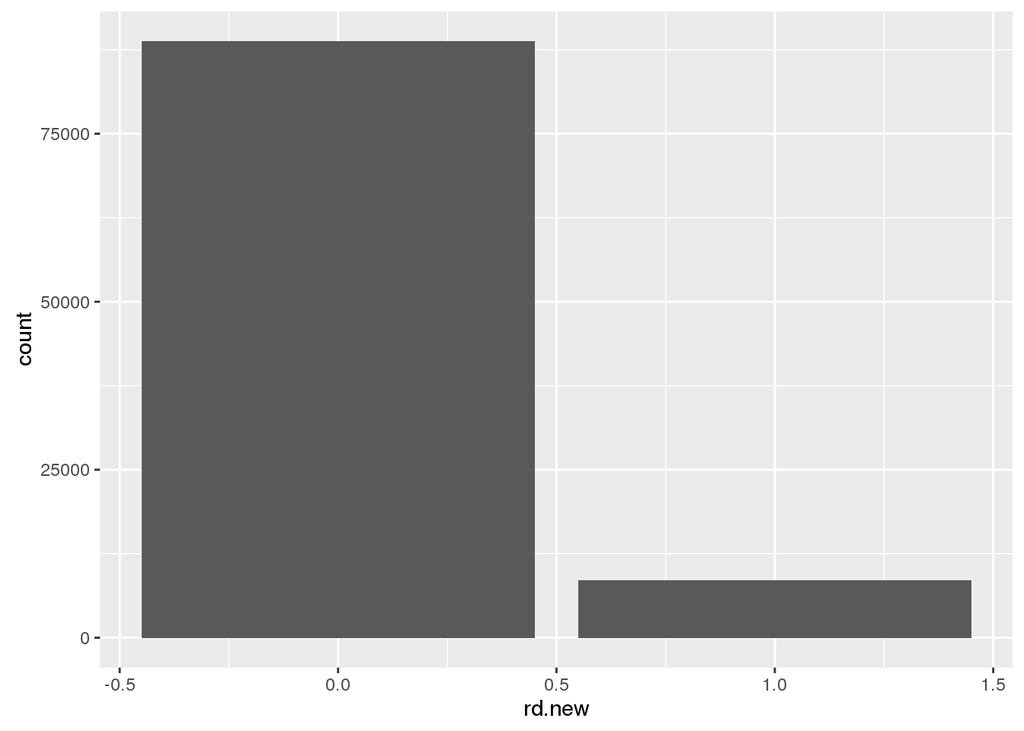

```r
ggplot(be2olak.data.filtered, aes(x = rd.new)) + geom_bar()
```

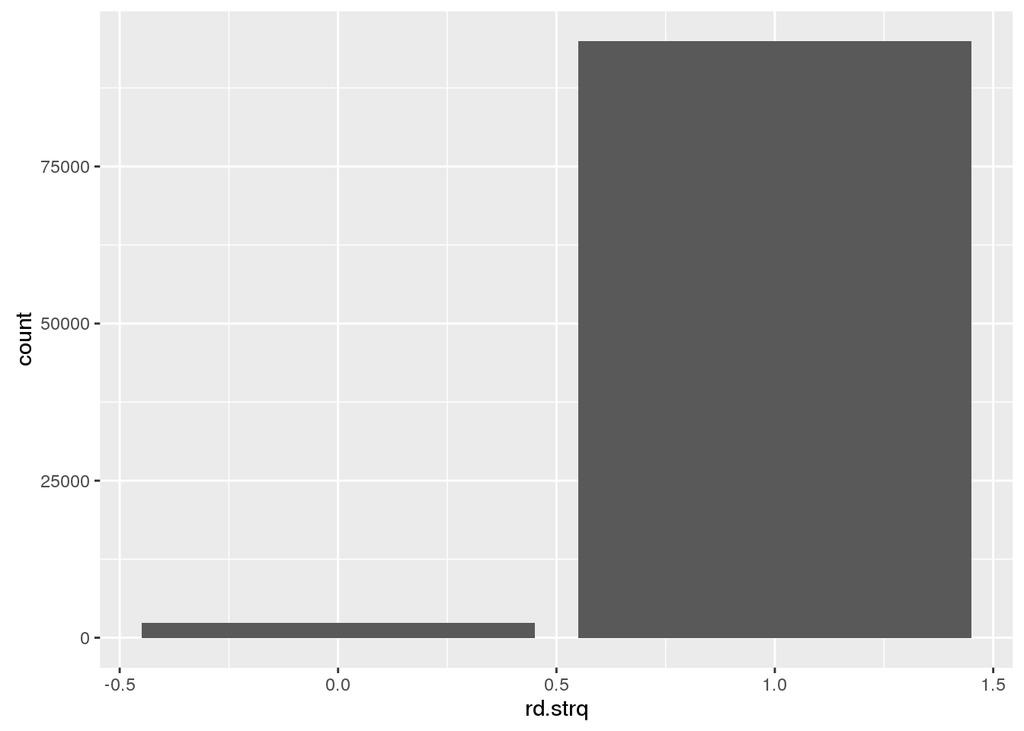

```r
ggplot(be2olak.data.filtered, aes(x = rd.strq)) + geom_bar()
```

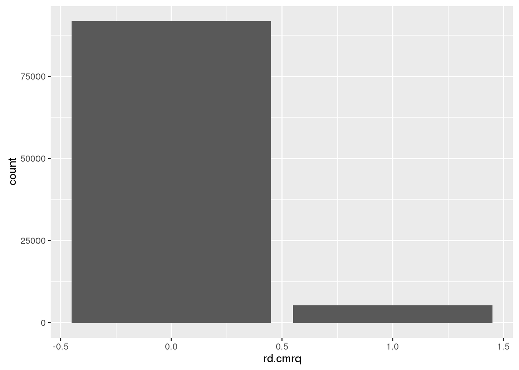

```r
ggplot(be2olak.data.filtered, aes(x = rd.cmrq)) + geom_bar()
```

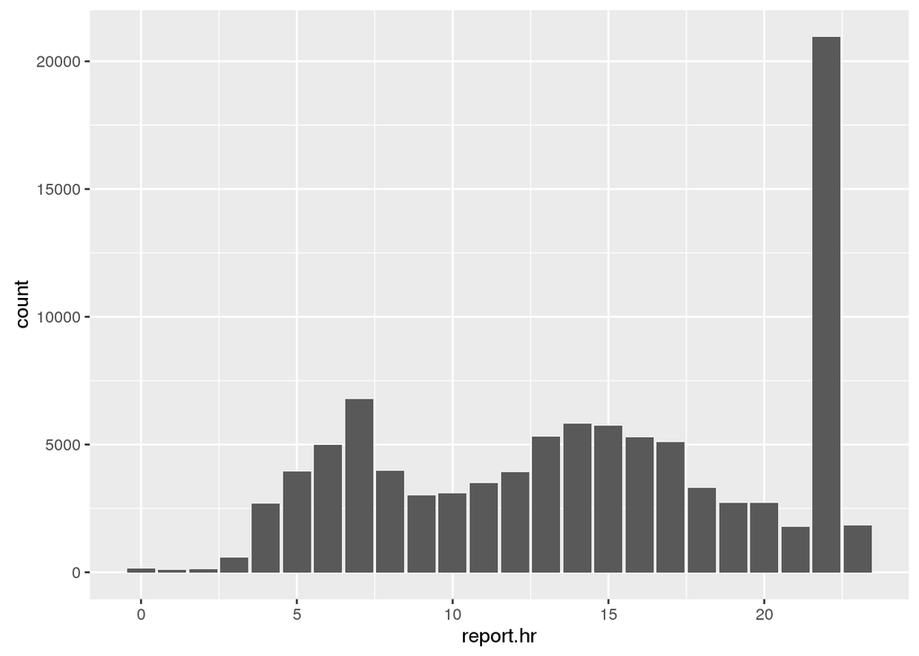

```r
ggplot(be2olak.data.filtered, aes(x = report.hr)) + geom_bar()
```

The above graph shows that the most hour reported in the 5 basic reports, is 22.

[figure not shown]

```r
# Factored Columns
ggplot(be2olak.data.filtered, aes(x = rd.nm)) + geom_bar() + coord_flip()
```

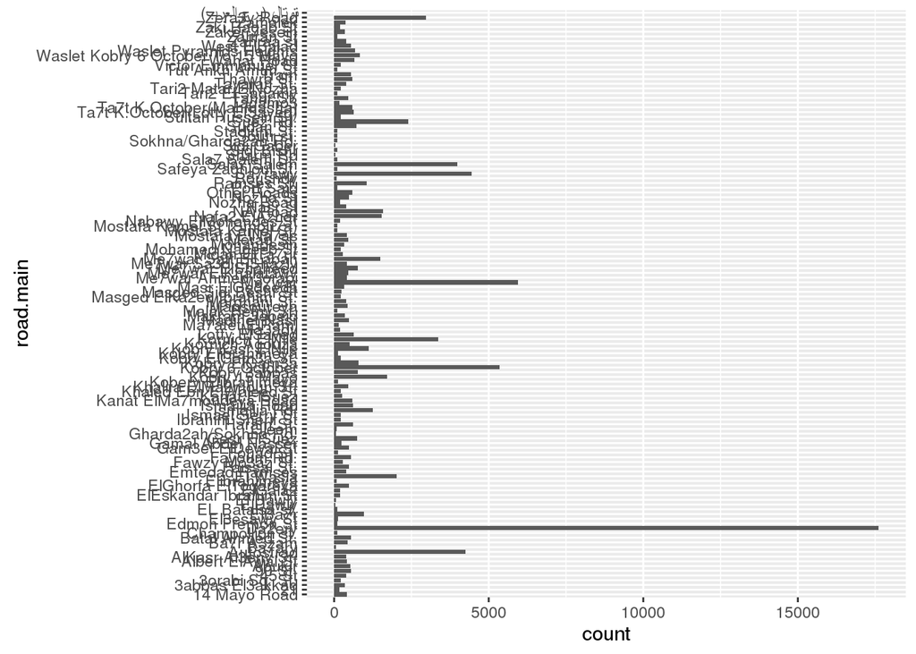

```r
ggplot(be2olak.data.filtered, aes(x = road.main)) + geom_bar() + coord_flip()
```

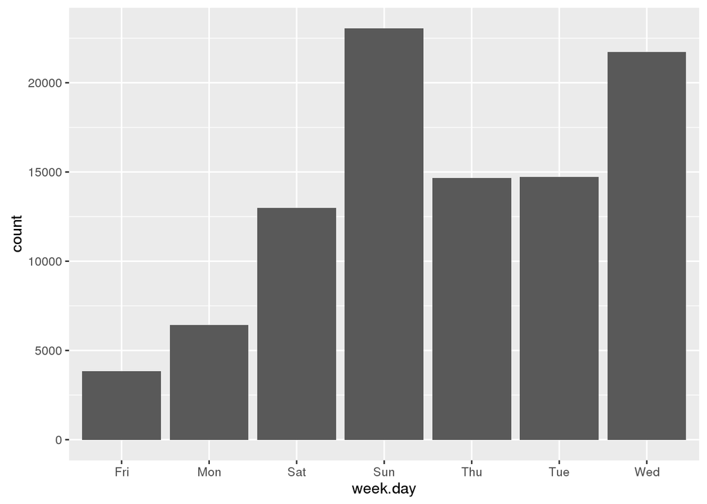

```r
ggplot(be2olak.data.filtered, aes(x = week.day)) + geom_bar()
```

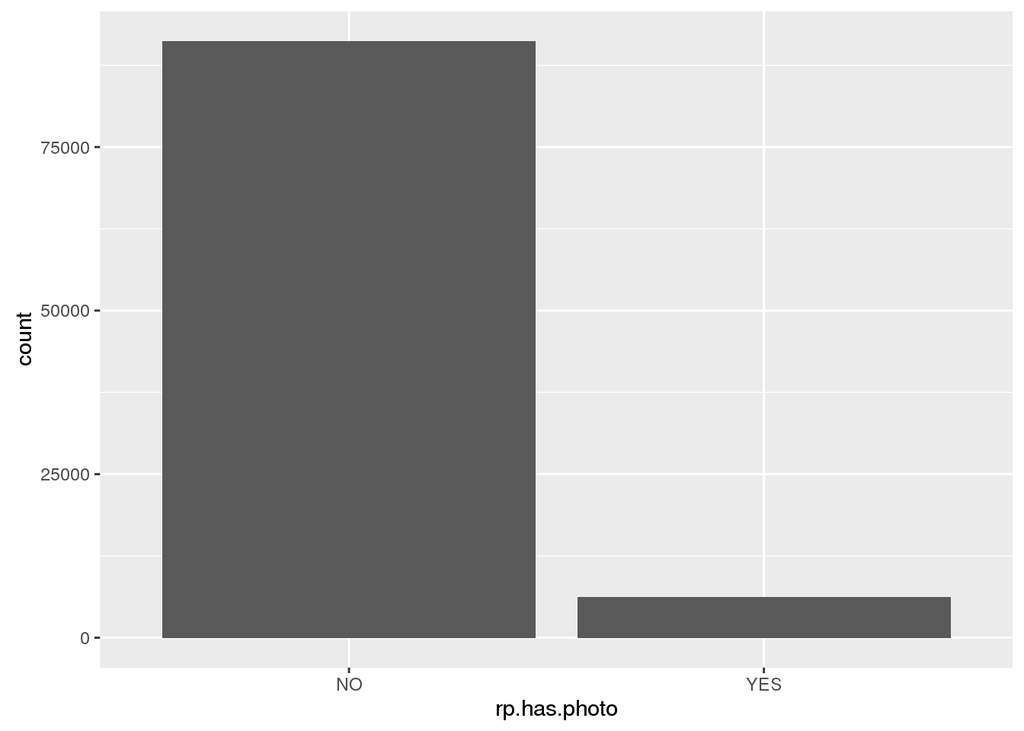

```r
ggplot(be2olak.data.filtered, aes(x = rp.has.photo)) + geom_bar()
```

Second Plotting the time column

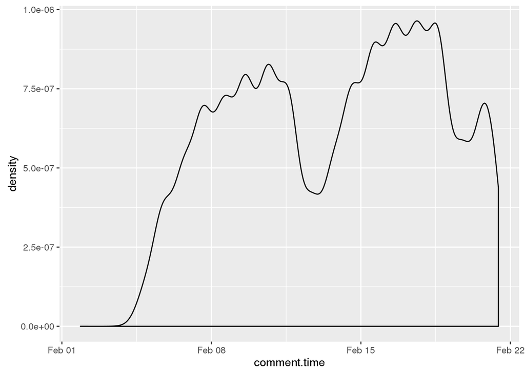

```r
ggplot(be2olak.data.filtered, aes(x = comment.time)) + geom_density()
```

### Visualising and Stating statistics for part of data

By Montoring Bey2ollak website, I was able to find most of those status look like:

- 1 –> :D –> 7alawa
- 2 –> :) –> Lazeez
- 3 –> :| –> Mashy
- 4 –> :( –> Zahma
- 5 –> :’( –> Mafeesh amal
- 6 –> So2al
- 7 –> Khatar
- 8 –> 7adsa
- 9 –> 3otl
- 10 –> Ba2ollak

Try to plot correlation matrix

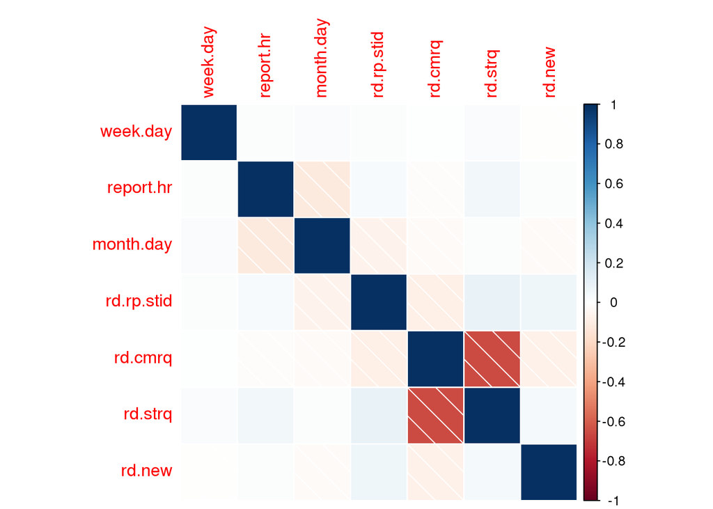

```r
be2olak.data.filtered$week.day <- as.integer(be2olak.data.filtered$week.day)
cor_feats = c("week.day", "report.hr", "month.day", "rd.rp.stid", "rd.cmrq",
    "rd.strq", "rd.new")
cor_mat = cor(be2olak.data.filtered[, cor_feats], use = "complete")
corrplot(method = "shade", cor_mat)
```

Of course one of the most important questions, that I am interested to prove is the that Friday would be the least time having “zahma” in all

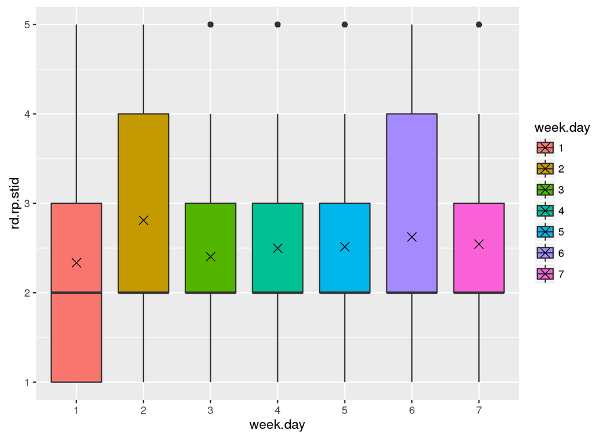

```r
be2olak.data.filtered$week.day <- as.factor(be2olak.data.filtered$week.day)

ggplot(be2olak.data.filtered, aes(y = rd.rp.stid, x = week.day, fill = week.day)) +
    geom_boxplot() + stat_summary(fun.y = mean, geom = "point", shape = 4, size = 3)
```

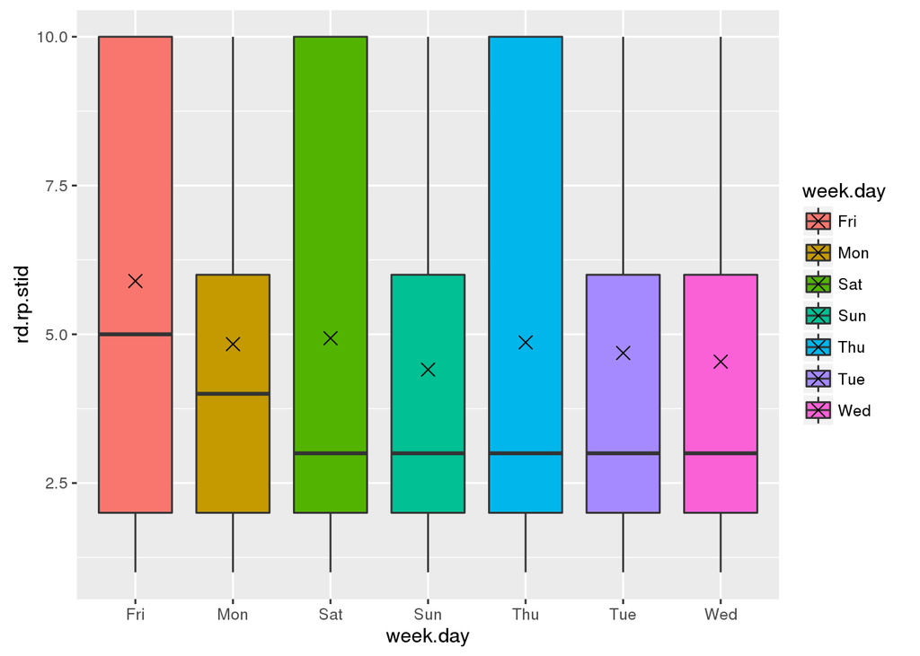

```r
ggplot(be2olak.data, aes(y = rd.rp.stid, x = week.day, fill = week.day)) + geom_boxplot() +
    stat_summary(fun.y = mean, geom = "point", shape = 4, size = 3)
```

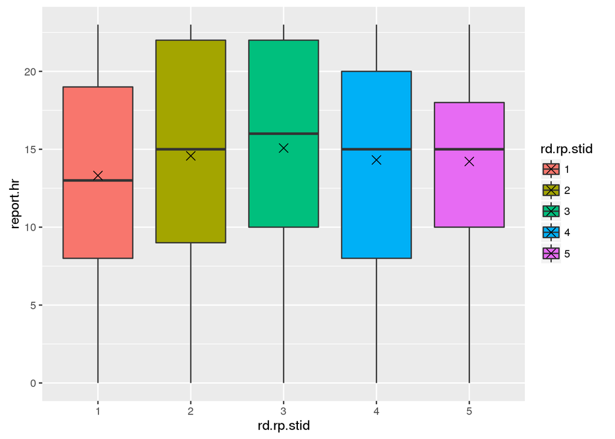

```r
be2olak.data.filtered$rd.rp.stid <- as.factor(be2olak.data.filtered$rd.rp.stid)

ggplot(be2olak.data.filtered, aes(y = report.hr, x = rd.rp.stid, fill = rd.rp.stid)) +
    geom_boxplot() + stat_summary(fun.y = mean, geom = "point", shape = 4, size = 3)
```

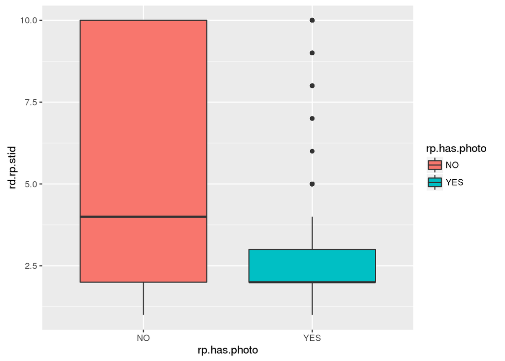

```r
ggplot(be2olak.data, aes(x = rp.has.photo, y = rd.rp.stid, fill = rp.has.photo)) +
    geom_boxplot()
```

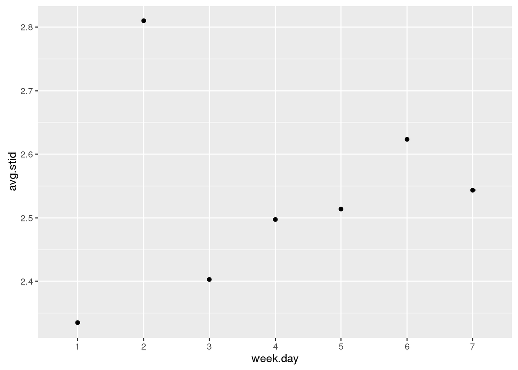

```r
be2olak.data.filtered$rd.rp.stid <- as.integer(be2olak.data.filtered$rd.rp.stid)

temp <- be2olak.data.filtered %>% group_by(week.day) %>% summarise(avg.stid = mean(rd.rp.stid))
ggplot(temp, aes(x = week.day, y = avg.stid)) + geom_point()
```

### Hypotheses

Here are some ideas for Hypotheses that could be tried

- [1] The ratio of negative reports in Cairo is much higher than in Alex.
- [2] The ratio of negative reports on Firday is less than any other day in the week.
- [3] In (3otl, 7adsa, khatar), the probabitity of uploading an image in a report is significantly higher than in normal times.
- [4] Leaving the default message of a status is higher than of write customized ones.
- [5] [7:30 am - 9 am] and [2 pm - 4 pm] have higher rate of negative reports than in other times of the day.